# Henry Fernandez - Loan Prediction

Step 1: Clean and prepare your data: There are several entries where values have been deleted to simulate dirty data. Please clean the data with whatever method(s) you believe is best/most suitable. Note that some of the missing values are truly blank (unknown answers) and thus may be impossible to clean; use your discretion.

## Data Cleaning and Preperation

```python
import pandas as pd
import numpy as np
import matplotlib.pyplot as plt
```

```python
import seaborn as sns
```

```python
%pwd
```

```
'C:\\Users\\hdfer\\OneDrive\\Desktop\\Henry\\Uchicago\\Quarter 2\\Data Mining Principles\\Week-6\\Assignment_3\\Loan_Prediction'
```

```python
data = pd.read_csv('Data for Cleaning & Modeling.csv')
data.head()
```

|  | X1 | X2 | X3 | X4 | X5 | X6 | X7 | X8 | X9 | X10 | ... | X23 | X24 | X25 | X26 | X27 | X28 | X29 | X30 | X31 | X32 |
| --- | --- | --- | --- | --- | --- | --- | --- | --- | --- | --- | --- | --- | --- | --- | --- | --- | --- | --- | --- | --- | --- |
| 0 | 11.89% | 54734.0 | 80364.0 | $25,000 | $25,000 | $19,080 | 36 months | B | B4 | NaN | ... | Feb-94 | 0.0 | NaN | NaN | 10.0 | 0.0 | 28854.0 | 52.10% | 42.0 | f |
| 1 | 10.71% | 55742.0 | 114426.0 | $7,000 | $7,000 | $673 | 36 months | B | B5 | CNN | ... | Oct-00 | 0.0 | NaN | NaN | 7.0 | 0.0 | 33623.0 | 76.70% | 7.0 | f |
| 2 | 16.99% | 57167.0 | 137225.0 | $25,000 | $25,000 | $24,725 | 36 months | D | D3 | Web Programmer | ... | Jun-00 | 0.0 | 41.0 | NaN | 10.0 | 0.0 | 19878.0 | 66.30% | 17.0 | f |
| 3 | 13.11% | 57245.0 | 138150.0 | $1,200 | $1,200 | $1,200 | 36 months | C | C2 | city of beaumont texas | ... | Jan-85 | 0.0 | 64.0 | NaN | 5.0 | 0.0 | 2584.0 | 40.40% | 31.0 | f |
| 4 | 13.57% | 57416.0 | 139635.0 | $10,800 | $10,800 | $10,692 | 36 months | C | C3 | State Farm Insurance | ... | Dec-96 | 1.0 | 58.0 | NaN | 14.0 | 0.0 | 3511.0 | 25.60% | 40.0 | f |

5 rows × 32 columns

```python
data.columns = ['interest_rate', 'loan_id', 'borrower_id', 'loan_requested','loan_funded','invester_portion','num_payments',
                'loan_grade','loan_subgrade','job_title','years_employed','home_ownership_status','borrower_annual_income',
                'income_verified','date_issued','loan_reason','loan_category','loan_title','zipcode_3','borrower_state',
                'ratio','num_pastdue','earliest_reported_date','num_creditor_inquiries','months_since_borrower_last_delinquency',
                'months_since_last_public_record','num_borrower_open_creditlines','num_derogatory_public_records',
                'credit_revolving_balance', 'revolving_line_utilization_rate','num_borrower_credit_lines','loan_initial_listing_status']
```

```python
data.head()
data.shape
```

```
(400000, 32)
```

```python
data.isna().sum()
```

```
interest_rate                              61010
loan_id                                        1
borrower_id                                    1
loan_requested                                 1
loan_funded                                    1
invester_portion                               1
num_payments                                   1
loan_grade                                 61270
loan_subgrade                              61270
job_title                                  23986
years_employed                             17538
home_ownership_status                      61361
borrower_annual_income                     61028
income_verified                                1
date_issued                                    1
loan_reason                               276440
loan_category                                  1
loan_title                                    19
zipcode_3                                      1
borrower_state                                 1
ratio                                          1
num_pastdue                                    1
earliest_reported_date                         1
num_creditor_inquiries                         1
months_since_borrower_last_delinquency    218802
months_since_last_public_record           348845
num_borrower_open_creditlines                  1
num_derogatory_public_records                  1
credit_revolving_balance                       1
revolving_line_utilization_rate              267
num_borrower_credit_lines                      1
loan_initial_listing_status                    1
dtype: int64
```

Columns with major missing values:

- Here:
  - interest_rate\
  - loan_grade (impute ?)
  - loan_subgrade
  - job_title
  - years_employed
  - home_ownership_status
  - borrower_annual_income
  - loan_reason
  - months_since_borrower_last_delinquency
  - months_since_last_public_record
  - revolving_line_utilization_rate (not missing too many)

#### Clean Interest Rate & Drop Missing Values

```python
data['interest_rate'] = data['interest_rate'].str.rstrip('%').astype('float')
```

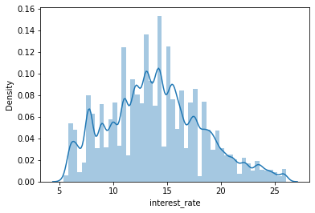

```python
data = data.dropna(subset=['interest_rate'])

sns.distplot(data[data['interest_rate'].notnull()]['interest_rate'])
```

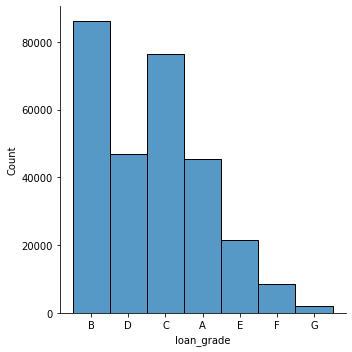

```python
sns.displot(data[data['loan_grade'].notnull()]['loan_grade'])
```

```python
# print(data.loan_grade.value_counts())
# data['loan_grade'] = data['loan_grade'].fillna('B')
```

```python
# sns.displot(data[data['loan_grade'].notnull()]['loan_grade'])
```

Probably shouldn't do this.

Fill loan subgrade nans. What's the best way to go about this ?

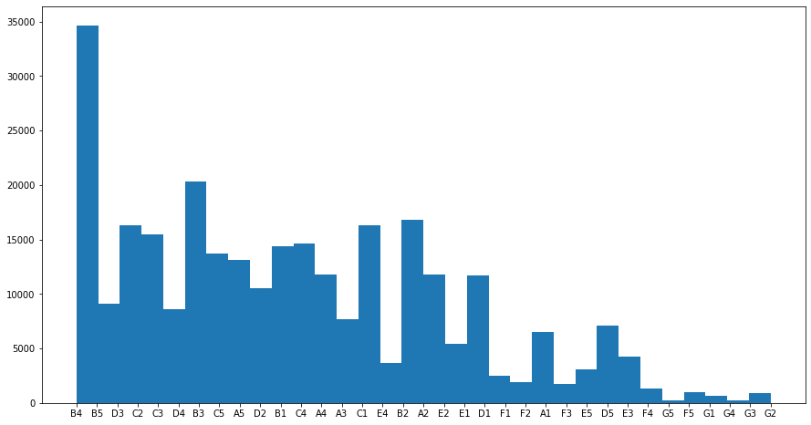

```python
plt.figure(figsize = (15,8))
plt.hist(x = data[data['loan_subgrade'].notnull()]['loan_subgrade'], bins = 32)
```

```python
# data['loan_subgrade'] = data['loan_subgrade'].fillna('B3')
# sns.displot(data[data['loan_subgrade'].notnull()]['loan_subgrade'])
```

Most common imputaiton for loan_subgrade doesn't work either. distribution is very messed up

Investigate Job Title Nans

```python
len(data.job_title.unique()) / len(data.job_title)
```

```
0.482008318829464
```

Almost half ot the job titles are unique. Not sure there is any useful predictive value here. Going to drop it

```python
data = data.drop('job_title',axis = 1)
```

Investiage Years Employed

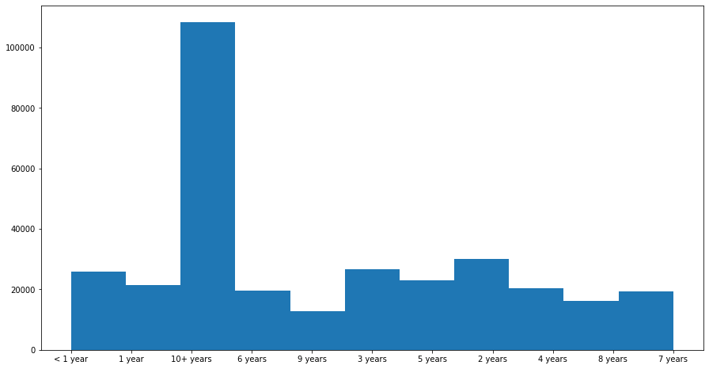

```python
plt.figure(figsize = (15,8))
plt.hist(x = data[data['years_employed'].notnull()]['years_employed'], bins = 11)
```

```python
data['years_employed'] = data['years_employed'].fillna('10+ years')
```

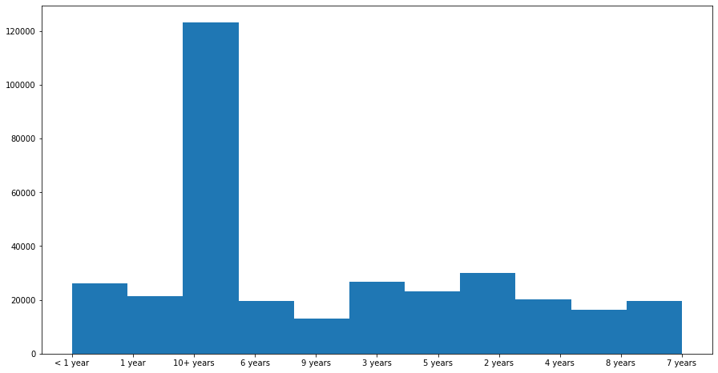

```python
plt.figure(figsize = (15,8))
plt.hist(x = data[data['years_employed'].notnull()]['years_employed'], bins = 11)
```

I'll keep this one for now. Distribution about the same.

```python
data.isna().sum()
```

```
interest_rate                                  0
loan_id                                        1
borrower_id                                    1
loan_requested                                 1
loan_funded                                    1
invester_portion                               1
num_payments                                   1
loan_grade                                 51867
loan_subgrade                              51867
years_employed                                 0
home_ownership_status                      51960
borrower_annual_income                     51752
income_verified                                1
date_issued                                    1
loan_reason                               233934
loan_category                                  1
loan_title                                    17
zipcode_3                                      1
borrower_state                                 1
ratio                                          1
num_pastdue                                    1
earliest_reported_date                         1
num_creditor_inquiries                         1
months_since_borrower_last_delinquency    185457
months_since_last_public_record           295590
num_borrower_open_creditlines                  1
num_derogatory_public_records                  1
credit_revolving_balance                       1
revolving_line_utilization_rate              225
num_borrower_credit_lines                      1
loan_initial_listing_status                    1
dtype: int64
```

#### Investigate home_ownership_status

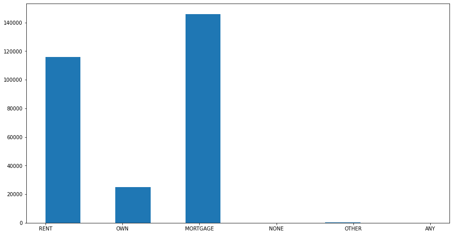

```python
plt.figure(figsize = (15,8))
plt.hist(x = data[data['home_ownership_status'].notnull()]['home_ownership_status'], bins = 11)
```

```python
data.home_ownership_status.value_counts()
```

```
MORTGAGE    145958
RENT        115958
OWN          24976
OTHER          107
NONE            30
ANY              1
Name: home_ownership_status, dtype: int64
```

```python
# not_useful_values = data.loc[(data['home_ownership_status'] == "NONE") | (data['home_ownership_status'] == "OTHER") | (data['home_ownership_status'] == "ANY") ]

# not_useful_values = not_useful_values.reset_index()
# not_useful_rows = not_useful_values.iloc[:,0]
# data = data.drop(data.index[not_useful_rows], axis = 0)
```

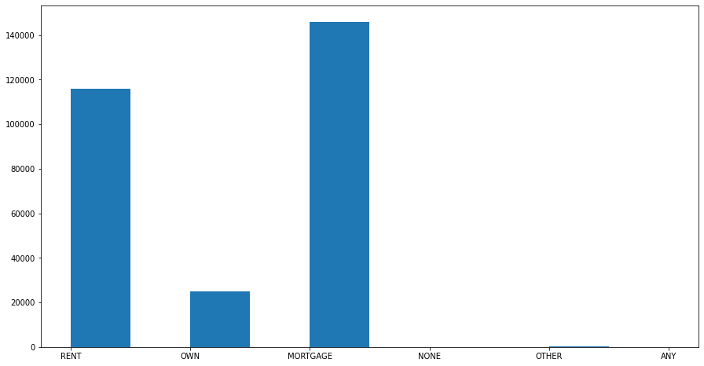

```python
plt.figure(figsize = (15,8))
plt.hist(x = data[data['home_ownership_status'].notnull()]['home_ownership_status'])
```

#### INVESTIGATE LOAN_REASON

```python
data.loan_reason.value_counts()
```

```
                                                                                                                                                                                                                                                                                                            …
Debt Consolidation                                                                                                                                                                                                                                                                                          …
  Borrower added on 03/10/14 > Debt consolidation<br>                                                                                                                                                                                                                                                       …
  Borrower added on 03/17/14 > Debt consolidation<br>                                                                                                                                                                                                                                                       …
  Borrower added on 02/19/14 > Debt consolidation<br>                                                                                                                                                                                                                                                       …
                                                                                                                                                                                                                                                                                                            …
  Borrower added on 07/11/12 > I have credit card debt with around 20% interest so I would like to consolidate them using this loan. Thank you for your time.<br>                                                                                                                                           …
  Borrower added on 07/18/12 > Remodeling Bathroom &amp; Closet. Need to buy Whirlpool Tub, Pedestal Sink, Faucets ( Sink/Tub), Flooring for Bathroom &amp; Closet, Wood (Bath/Closet), Light Fixtures (B/C), Racks, Poles , Nails, Screws, etc.<br>                                                        …
  Borrower added on 07/11/12 > This loan will help to replace a roof that is badly needed on our single family home.<br><br>  Borrower added on 07/12/12 > This loan will replace a roof and subtract from the cost of new windows to improve the property value so that we may refinance down to a 15 year …
  Borrower added on 07/11/12 > This loan is to consolidate debt.  All my finances are in good order with no late payments on any accounts.  I own my home and am employed full time.<br>                                                                                                                    …
  Borrower added on 03/18/14 > Consolidating debt into one account.<br>                                                                                                                                                                                                                                     …
Name: loan_reason, Length: 103869, dtype: int64
```

```python
data = data.drop('loan_reason', axis = 1)
```

No predictive value here

#### INVESTIGATE LOAN_TITLE

```python
len(data.loan_title.unique())
```

```
53618
```

```python
data = data.drop('loan_title', axis = 1)
```

#### INVESTIGATE MONTHS SINCE BORROWER LAST DELINQUENCY

```python
len(data.months_since_borrower_last_delinquency.unique())
```

```
141
```

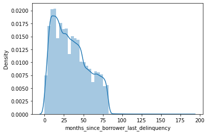

```python
sns.distplot(data.months_since_borrower_last_delinquency)
```

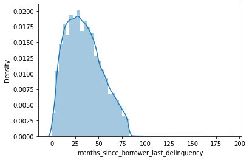

```python
data['months_since_borrower_last_delinquency'] = data['months_since_borrower_last_delinquency'].interpolate()
sns.distplot(data.months_since_borrower_last_delinquency)
```

Distribution is relatively similar. Feels ok to keep.

#### INVESTIGATE months_since_last_public_record

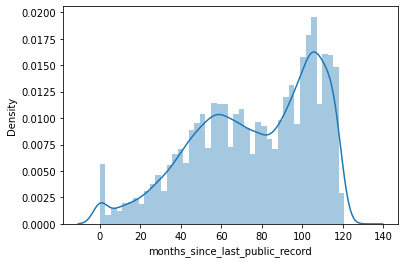

```python
sns.distplot(data.months_since_last_public_record)
```

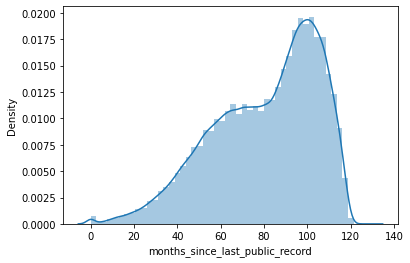

```python
data['months_since_last_public_record'] = data['months_since_last_public_record'].interpolate()
sns.distplot(data.months_since_last_public_record)
```

This was a good interpolation. Happy with this.

#### Interpolate revolving_line_utilization_rate

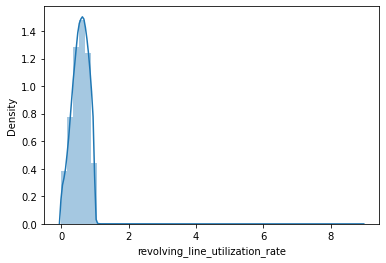

```python
data['revolving_line_utilization_rate'] = data['revolving_line_utilization_rate'].str.rstrip('%').astype('float') / 100.0
sns.distplot(data.revolving_line_utilization_rate)
```

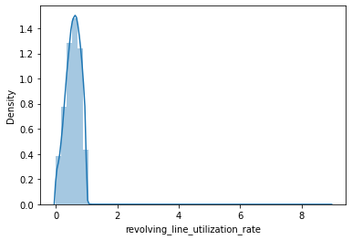

```python
data['revolving_line_utilization_rate'] = data['revolving_line_utilization_rate'].interpolate()
sns.distplot(data.revolving_line_utilization_rate)
```

That looks good! We'll keep it :)

## OK, those were the variables with missing values. Let's quickly investigate the other variables

```python
comparison_column = np.where(data["loan_funded"] == data["loan_requested"], True, False)
print(sum(comparison_column))
print(len(comparison_column))
```

```
337338
338990
```

#### Drop loan_funded, years_employed, loan_id and borrower_id, date issued, and zipcode

```python
data = data.drop('loan_funded',axis = 1)
data = data.drop('zipcode_3',axis = 1)
data = data.drop('years_employed',axis=1)
data = data.drop(['loan_id','borrower_id'],axis = 1)
data = data.drop('date_issued', axis = 1)
```

```python
data.income_verified.value_counts()
```

```
VERIFIED - income           127040
not verified                107873
VERIFIED - income source    104076
Name: income_verified, dtype: int64
```

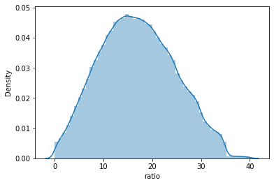

```python
sns.distplot(data.ratio)
```

```python
data.num_pastdue.value_counts()
```

```
0.0     280249
1.0      39796
2.0      11494
3.0       3964
4.0       1658
5.0        841
6.0        441
7.0        226
8.0        111
9.0         68
10.0        48
11.0        27
12.0        23
13.0        13
18.0         6
14.0         6
16.0         5
15.0         4
17.0         3
19.0         2
24.0         1
29.0         1
22.0         1
21.0         1
Name: num_pastdue, dtype: int64
```

```python
data.loan_category.value_counts()
```

```
debt_consolidation    198226
credit_card            75680
home_improvement       19625
other                  17154
major_purchase          7312
small_business          5359
car                     4115
medical                 3329
moving                  2138
wedding                 1934
vacation                1848
house                   1723
educational              279
renewable_energy         267
Name: loan_category, dtype: int64
```

```python
data.info()
```

```
<class 'pandas.core.frame.DataFrame'>
Int64Index: 338990 entries, 0 to 399999
Data columns (total 23 columns):
 #   Column                                  Non-Null Count   Dtype
---  ------                                  --------------   -----
 0   interest_rate                           338990 non-null  float64
 1   loan_requested                          338989 non-null  object
 2   invester_portion                        338989 non-null  object
 3   num_payments                            338989 non-null  object
 4   loan_grade                              287123 non-null  object
 5   loan_subgrade                           287123 non-null  object
 6   home_ownership_status                   287030 non-null  object
 7   borrower_annual_income                  287238 non-null  float64
 8   income_verified                         338989 non-null  object
 9   loan_category                           338989 non-null  object
 10  borrower_state                          338989 non-null  object
 11  ratio                                   338989 non-null  float64
 12  num_pastdue                             338989 non-null  float64
 13  earliest_reported_date                  338989 non-null  object
 14  num_creditor_inquiries                  338989 non-null  float64
 15  months_since_borrower_last_delinquency  338988 non-null  float64
 16  months_since_last_public_record         338983 non-null  float64
 17  num_borrower_open_creditlines           338989 non-null  float64
 18  num_derogatory_public_records           338989 non-null  float64
 19  credit_revolving_balance                338989 non-null  float64
 20  revolving_line_utilization_rate         338990 non-null  float64
 21  num_borrower_credit_lines               338989 non-null  float64
 22  loan_initial_listing_status             338989 non-null  object
dtypes: float64(12), object(11)
memory usage: 62.1+ MB
```

```python
interest_rate = data['interest_rate']
```

#### Investigate state, does it have any relationship with interest rate?

```python
# state = pd.get_dummies(data, columns = ['borrower_state'])
# droplist = np.arange(0, 23,1).tolist()
# state.drop(state.columns[droplist], axis=1, inplace=True)
# state['y'] = interest_rate
```

```python
data = data.drop('borrower_state', axis = 1)
```

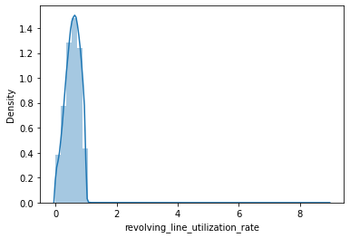

```python
sns.distplot(data.revolving_line_utilization_rate)
```

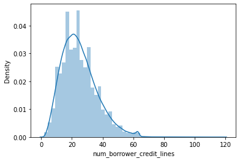

```python
sns.distplot(data.num_borrower_credit_lines)
```

```python
data.loan_initial_listing_status.value_counts()
```

```
f    232600
w    106389
Name: loan_initial_listing_status, dtype: int64
```

## Instead of dumping all the variables in the model, let's look to see if there are any relationships beetween the features and the interest rate

#### Loan Requested

```python
# sns.set(style = 'whitegrid')
# sns.scatterplot(x = data['loan_requested'], y=data['interest_rate'], size = 6)
# # ax.map(sns.pointplot)
# # ax.set(ylim = (0,1))
```

#### Number of Payments

```python
data.num_payments.value_counts()
```

```
 36 months    247791
 60 months     91198
Name: num_payments, dtype: int64
```

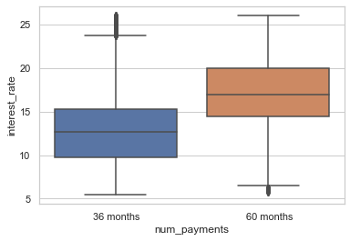

```python
sns.set(style = 'whitegrid')
ax = sns.boxplot(x = data['num_payments'], y= data['interest_rate'])
# ax.map(sns.pointplot)
# ax.set(ylim = (0,1))
```

#### Loan Grade

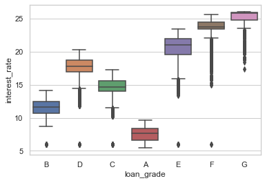

```python
sns.set(style = 'whitegrid')
ax = sns.boxplot(x = data['loan_grade'], y= data['interest_rate'])
# ax.map(sns.pointplot)
# ax.set(ylim = (0,1))
```

Ok very Important here. A Grades have the lowest average interests rate, ascneding to G.

#### Loan Subgrade

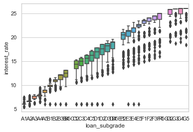

```python
sns.set(style = 'whitegrid')
ax = sns.boxplot(x = data['loan_subgrade'], y= data['interest_rate'], order = ['A1','A2','A3','A4','A5','B1','B2','B3','B4','B5'
                                                                            'C1','C2','C3','C4','C5','D1','D2','D3','D4','D5'
                                                                            'E1','E2','E3','E4','E5','F1','F2','F3','F4','F5'
                                                                            'G1','G2','G3','G4','G5'])
# ax.map(sns.pointplot)
# ax.set(ylim = (0,1))
```

Loan Subgrade also seems like it is useful for ML. Will keep.

#### Home Ownership Status

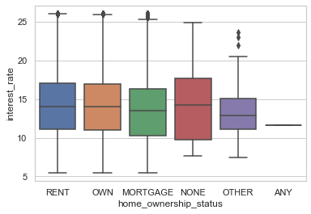

```python
sns.set(style = 'whitegrid')
ax = sns.boxplot(x = data['home_ownership_status'], y= data['interest_rate'])
# ax.map(sns.pointplot)
# ax.set(ylim = (0,1))
```

Doesn't seem super helfpul. Can probably drop.

#### Borrower Annual Income

```
[(0.0, 1000000.0)]
```

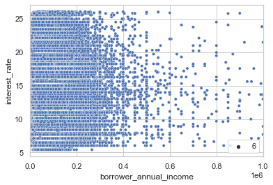

```python
sns.set(style = 'whitegrid')
ax = sns.scatterplot(x = data['borrower_annual_income'], y=data['interest_rate'], size = 6)
ax.set(xlim = (0,1e6))
```

```python
data['interest_rate'].corr(data['borrower_annual_income'])
```

```
-0.03220667298316868
```

Not super sure about this one

#### Income Verified

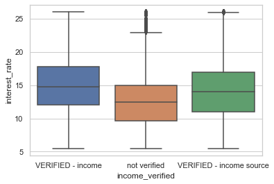

```python
sns.set(style = 'whitegrid')
ax = sns.boxplot(x = data['income_verified'], y= data['interest_rate'])
# ax.map(sns.pointplot)
# ax.set(ylim = (0,1))
```

Decent. Fine to keep I think

#### Loan Category

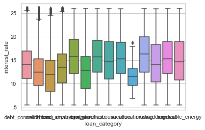

```python
sns.set(style = 'whitegrid')
ax = sns.boxplot(x = data['loan_category'], y= data['interest_rate'])
# ax.map(sns.pointplot)
# ax.set(ylim = (0,1))
```

#### Ratio

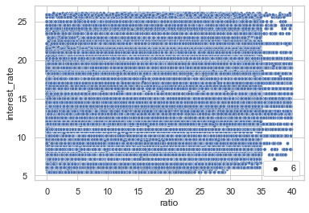

```python
sns.set(style = 'whitegrid')
ax = sns.scatterplot(x = data['ratio'], y=data['interest_rate'], size = 6)
```

#### Num Pastdue

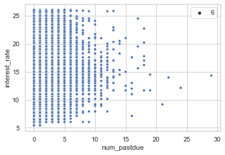

```python
sns.set(style = 'whitegrid')
ax = sns.scatterplot(x = data['num_pastdue'], y=data['interest_rate'], size = 6)
```

#### Num_creditor_inquiries

```python
data['interest_rate'].corr(data['num_pastdue'])
```

```
0.09166122920703024
```

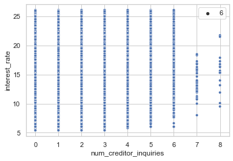

```python
sns.set(style = 'whitegrid')
ax = sns.scatterplot(x = data['num_creditor_inquiries'], y=data['interest_rate'], size = 6)
```